# Longitudinal Data Analysis

04/18/2018

## Two Stage Models

## Two-Stage (Two-Level) Formulation

- We will proceed with Linear Mixed effects models.
- They are very useful in longitudinal as well as other hierarchical aspects.
- The basic idea of the model is that we assume
  1. **Stage 1**: A straight line (or more generally a "growth" curve) fits the observed responses for each subject.
  2. **Stage 2**: A Regression model relating the mean of the individual intercepts and slopes to the subject specific effects.

## Stage 1

- In the first stage we assume that all subjects have their own unique trajectory.
- So for subject \(i\): \[Y_{ij}= Z_{ij}\beta_i + \varepsilon_{ij}, \qquad j=1,\ldots,n_i\]
- where \(\beta_i\) is a vector of subject-specific regression parameters, the errors are typically considered independent within a subject.

## Stage 1: Subject Specific Effects

- Many times we use a model with subject specific intercepts and slope: \[Y_{ij} = \beta_{1i} + \beta_{2i}t_{ij} + e_{ij}\]
- So in stage 1 each subject has their own unique regression model.
  - Basically we allow each subject to have their own line.
  - We restrict the covariates in these models to be ones that vary over time.
- Any covariates that do not vary over time or refer to between-subject changes (sex, gender, treatment group, exposure group,…) are not included at this stage.

## Stage 2

- In this stage we assume that the \(\beta_i\)'s (subject-specific effects) are random and come from some distribution (IE. normal or some other).
- We then model the mean and covariance of the \(\beta_i\)'s in the population. \[\beta_i = A_i \beta + b_i, \text{ where } b_i \sim N(0,G)\]

## Stage 2

- Where
  - \(A_i\) are the between subject covariates
  - \(b_i = \left( \begin{array}{c} b_{1i}\\ b_{2i}\\ \end{array}\right)\) are the random effects for individuals
  - \(G= \left[ \begin{array}{cc} var(b_{1i}) & cov(b_{1i},b_{2i})\\ cov(b_{1i},b_{2i}) & var(b_{2i})\\ \end{array} \right]\) is the covariance matrix for the subject specific effects.

## Quick Example

- Consider a treatment vs control setting where we have subject specific intercept, \(\beta_{1i}\), and slope \(\beta_{2i}\).
- Then we would model the subject specific effects with a group effect:

\[\begin{aligned} E(\beta_{1i} ) &= \beta_1 + \beta_2 \text{GROUP}_i\\ E(\beta_{2i} ) &= \beta_3 + \beta_4 \text{GROUP}_i\\ \end{aligned}\]

## Quick Example

- Where \(\text{GROUP}_i\) is an indicator variable for treatment.
- Then in this example we would have the following models for means:

## Quick Example

- For the control group: \[\begin{aligned} E(\beta_{1i} ) &= \beta_1\\ E(\beta_{2i} ) &= \beta_3 \\ \end{aligned}\]

## Quick Example

- for the treatment group:

\[\begin{aligned} E(\beta_{1i} ) &= \beta_1 + \beta_2\\ E(\beta_{2i} ) &= \beta_3 + \beta_4\\ \end{aligned}\]

## How do we fit these models:

- One approach has been coined as the "NIH Method" since it was popularized by statisticians working at the NIH.
- What they did was:
  1. Fit a regression to the response data for each subject.
  2. Regress the estimates of the individual intercepts and slopes on subject specific covariates.
- This method was very easy to perform because it did not require any special form of regression software.
- This works very well with balanced data.

## Mixed Effects Models

## Mixed Effects Models

- In contrast what we tend to do now is consider a *Mixed Effects* model that contains the 2 stages but fits everything all at once:

\[\begin{aligned} Y_{ij} &= Z_{ij}\beta_i + \varepsilon_{ij}\\ &= Z_{ij}(A_i \beta + b_i) + \varepsilon_{ij}\\ &= Z_{ij}A_i \beta + Z_{ij}b_i + \varepsilon_{ij}\\ &= X_{ij}\beta + Z_{ij}b_i + \varepsilon_{ij}\\ \end{aligned}\]

## Mixed Effects Models

- We then have:
  - \(X_{ij}\beta\) fixed effects (population)
  - \(Z_{ij}b_i\) random effects (individual)

## An Example

- To illustrate this we consider a study done on orthodontic measurement.
- Investigators at the University of North Carolina Dental School followed the growth of 27 children (16 males, 11 females) from age 8 until age 14.
- Every two years they measured the distance between the pituitary and the pterygomaxillary fissure, two points that are easily identified on x-ray exposures of the side of the head.

## An Example

```r
library(nlme)
head(Orthodont)
Orthodont$age <- Orthodont$age - 8
```

```
## Grouped Data: distance ~ age | Subject
##   distance age Subject  Sex
## 1     26.0   8     M01 Male
## 2     25.0  10     M01 Male
## 3     29.0  12     M01 Male
## 4     31.0  14     M01 Male
## 5     21.5   8     M02 Male
## 6     22.5  10     M02 Male
```

## Example: Another Spaghetti Plot

```r
library(lattice)
xyplot( distance ~ age , data= Orthodont, groups=Subject, type='l', auto.key=list(space="top", columns=4,
                       title="Subject", cex.title=1), main="Distance")
```

## Example: Another Spaghetti Plot

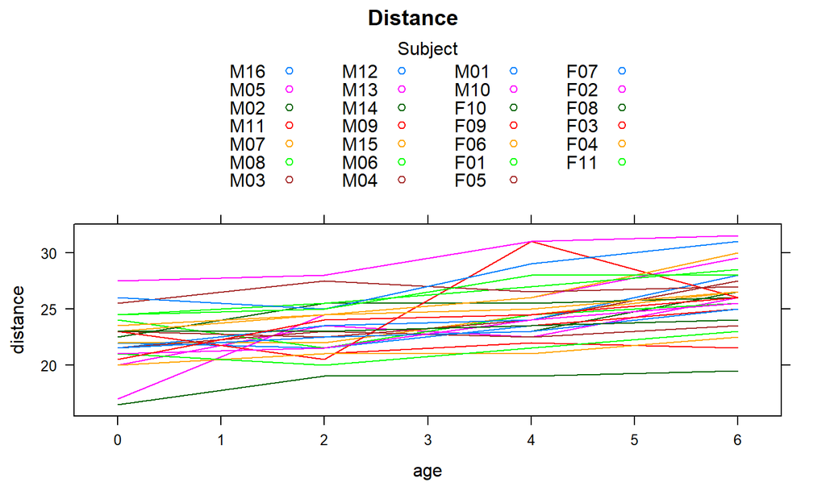

## What do you see?

## 2 Stage Approach

- Now in the 2 stage approach we first would model the change in distance for each individual.

```r
library(nlme)
reg.list <- lmList(distance ~ age, data=Orthodont)
summary(reg.list)
```

```r
library(nlme)
reg.list <- lmList(distance ~ age, data=Orthodont)
summary(reg.list)
```

## 2 Stage Approach

```
Call:
  Model: distance ~ age | Subject
   Data: Orthodont

Coefficients:
   (Intercept)
    Estimate Std. Error t value Pr(>|t|)
M16     21.4        1.1    19.5 4.36e-26
M05     20.4        1.1    18.7 3.32e-25
M02     21.1        1.1    19.2 8.51e-26
M11     22.7        1.1    20.7 2.60e-27
M07     21.4        1.1    19.5 4.36e-26
M08     22.8        1.1    20.8 2.10e-27
M03     22.0        1.1    20.1 1.05e-26
M12     21.2        1.1    19.4 5.44e-26
M13     18.4        1.1    16.8 4.37e-23
M14     23.3        1.1    21.3 6.64e-28
M09     22.2        1.1    20.3 6.79e-27
M15     22.5        1.1    20.5 3.57e-27
M06     24.4        1.1    22.2 7.81e-29
M04     26.1        1.1    23.8 2.59e-30
M01     24.9        1.1    22.7 2.62e-29
M10     27.2        1.1    24.9 3.05e-31
F10     17.1        1.1    15.6 1.03e-21
F09     20.3        1.1    18.5 4.69e-25
F06     20.0        1.1    18.2 9.39e-25
F01     20.2        1.1    18.5 5.26e-25
F05     21.8        1.1    19.9 1.62e-26
F07     21.4        1.1    19.5 4.36e-26
F02     20.6        1.1    18.8 2.36e-25
F08     22.9        1.1    20.8 1.70e-27
F03     21.2        1.1    19.3 6.09e-26
F04     23.5        1.1    21.4 4.87e-28
F11     24.4        1.1    22.2 7.81e-29
```

## 2 Stage Approach

```
   age
    Estimate Std. Error t value Pr(>|t|)
M16    0.550      0.293   1.878 6.58e-02
M05    0.850      0.293   2.902 5.36e-03
M02    0.775      0.293   2.646 1.07e-02
M11    0.325      0.293   1.109 2.72e-01
M07    0.800      0.293   2.731 8.51e-03
M08    0.375      0.293   1.280 2.06e-01
M03    0.750      0.293   2.560 1.33e-02
M12    1.000      0.293   3.414 1.22e-03
M13    1.950      0.293   6.657 1.49e-08
M14    0.525      0.293   1.792 7.87e-02
M09    0.975      0.293   3.328 1.58e-03
M15    1.125      0.293   3.840 3.25e-04
M06    0.675      0.293   2.304 2.51e-02
M04    0.175      0.293   0.597 5.53e-01
M01    0.950      0.293   3.243 2.03e-03
M10    0.750      0.293   2.560 1.33e-02
F10    0.450      0.293   1.536 1.30e-01
F09    0.275      0.293   0.939 3.52e-01
F06    0.375      0.293   1.280 2.06e-01
F01    0.375      0.293   1.280 2.06e-01
F05    0.275      0.293   0.939 3.52e-01
F07    0.550      0.293   1.878 6.58e-02
F02    0.800      0.293   2.731 8.51e-03
F08    0.175      0.293   0.597 5.53e-01
F03    0.850      0.293   2.902 5.36e-03
F04    0.475      0.293   1.622 1.11e-01
F11    0.675      0.293   2.304 2.51e-02

Residual standard error: 1.31 on 54 degrees of freedom
```

## Abstract Coefficients

- We can then abstract the estimated model coefficients and the variance-covariance matrices:

```r
b <- lapply(reg.list, coef)
b
V <- lapply(reg.list, vcov)
V
```

## Abstract Coefficients

```
## $M16
## (Intercept)         age
##       21.35        0.55
##
## $M05
## (Intercept)         age
##       20.45        0.85
##
## $M02
## (Intercept)         age
##      21.050       0.775
##
## $M11
## (Intercept)         age
##      22.650       0.325
##
## $M07
## (Intercept)         age
##        21.4         0.8
##
## $M08
## (Intercept)         age
##      22.750       0.375
##
## $M03
## (Intercept)         age
##       22.00        0.75
##
## $M12
## (Intercept)         age
##        21.2         1.0
##
## $M13
## (Intercept)         age
##       18.40        1.95
##
## $M14
## (Intercept)         age
##      23.300       0.525
##
```

[output cut: 52 more lines]

```
## $F08
## (Intercept)         age
##      22.850       0.175
##
## $F03
## (Intercept)         age
##       21.20        0.85
##
## $F04
## (Intercept)         age
##      23.450       0.475
##
## $F11
## (Intercept)         age
##      24.350       0.675
```

## Abstract Coefficients

```r
V <- lapply(reg.list, vcov)
V
```

```
## $M16
##             (Intercept)     age
## (Intercept)       0.508 -0.1088
## age              -0.109  0.0363
##
## $M05
##             (Intercept)    age
## (Intercept)       1.417 -0.304
## age              -0.304  0.101
##
## $M02
##             (Intercept)     age
## (Intercept)       0.761 -0.1631
## age              -0.163  0.0544
##
## $M11
##             (Intercept)     age
## (Intercept)      0.2013 -0.0431
## age             -0.0431  0.0144
##
## $M07
##             (Intercept)     age
## (Intercept)       0.508 -0.1088
## age              -0.109  0.0363
##
## $M08
##             (Intercept)    age
## (Intercept)       2.056 -0.441
## age              -0.441  0.147
##
## $M03
##             (Intercept)  age
## (Intercept)         1.4 -0.3
## age                -0.3  0.1
##
## $M12
##             (Intercept)     age
## (Intercept)       0.787 -0.1687
## age              -0.169  0.0562
##
```

[output cut: 79 more lines]

```
##
## $F03
##             (Intercept)    age
## (Intercept)       0.630 -0.135
## age              -0.135  0.045
##
## $F04
##             (Intercept)      age
## (Intercept)      0.0613 -0.01313
## age             -0.0131  0.00438
##
## $F11
##             (Intercept)     age
## (Intercept)       0.551 -0.1181
## age              -0.118  0.0394
```

## Abstract Coefficients

- An indicator variable of the estimate type (alternating intercept and slope) and a subject id variable are also needed, which can be created with:

```r
estm <- rep(c("intercept","slope"), length(b))
estm
subj <- rep(names(b), each=2)
subj
```

## Abstract Coefficients

```
##  [1] "intercept" "slope"     "intercept" "slope"     "intercept"
##  [6] "slope"     "intercept" "slope"     "intercept" "slope"
## [11] "intercept" "slope"     "intercept" "slope"     "intercept"
## [16] "slope"     "intercept" "slope"     "intercept" "slope"
## [21] "intercept" "slope"     "intercept" "slope"     "intercept"
## [26] "slope"     "intercept" "slope"     "intercept" "slope"
## [31] "intercept" "slope"     "intercept" "slope"     "intercept"
## [36] "slope"     "intercept" "slope"     "intercept" "slope"
## [41] "intercept" "slope"     "intercept" "slope"     "intercept"
## [46] "slope"     "intercept" "slope"     "intercept" "slope"
## [51] "intercept" "slope"     "intercept" "slope"
##  [1] "M16" "M16" "M05" "M05" "M02" "M02" "M11" "M11" "M07" "M07" "M08"
## [12] "M08" "M03" "M03" "M12" "M12" "M13" "M13" "M14" "M14" "M09" "M09"
## [23] "M15" "M15" "M06" "M06" "M04" "M04" "M01" "M01" "M10" "M10" "F10"
## [34] "F10" "F09" "F09" "F06" "F06" "F01" "F01" "F05" "F05" "F07" "F07"
## [45] "F02" "F02" "F08" "F08" "F03" "F03" "F04" "F04" "F11" "F11"
```

## Variance Covariance

- Next, we create one long vector with the model coefficients and the corresponding block-diagonal variance-covariance matrix with (the metafor package needs to be loaded for the bldiag() function):

```r
library(metafor)
b <- unlist(b)
V <- bldiag(V)
```

## Variance Covariance

[output not shown]

```
## M16.(Intercept)         M16.age M05.(Intercept)         M05.age
##          21.350           0.550          20.450           0.850
## M02.(Intercept)         M02.age M11.(Intercept)         M11.age
##          21.050           0.775          22.650           0.325
## M07.(Intercept)         M07.age M08.(Intercept)         M08.age
##          21.350           0.800          22.750           0.375
## M03.(Intercept)         M03.age M12.(Intercept)         M12.age
##          22.000           0.750          21.250           1.000
## M13.(Intercept)         M13.age M14.(Intercept)         M14.age
##          18.400           1.950          23.300           0.525
## M09.(Intercept)         M09.age M15.(Intercept)         M15.age
##          22.200           0.975          22.500           1.125
## M06.(Intercept)         M06.age M04.(Intercept)         M04.age
##          24.350           0.675          26.100           0.175
## M01.(Intercept)         M01.age M10.(Intercept)         M10.age
##          24.900           0.950          27.250           0.750
## F10.(Intercept)         F10.age F09.(Intercept)         F09.age
##          17.150           0.450          20.300           0.275
## F06.(Intercept)         F06.age F01.(Intercept)         F01.age
##          20.000           0.375          20.250           0.375
## F05.(Intercept)         F05.age F07.(Intercept)         F07.age
##          21.800           0.275          21.350           0.550
## F02.(Intercept)         F02.age F08.(Intercept)         F08.age
##          20.600           0.800          22.850           0.175
## F03.(Intercept)         F03.age F04.(Intercept)         F04.age
##          21.200           0.850          23.450           0.475
## F11.(Intercept)         F11.age
##          24.350           0.675
```

## Variance Covariance

```
##         [,1]    [,2]   [,3]   [,4]   [,5]    [,6]    [,7]    [,8]   [,9]
##  [1,]  0.508 -0.1088  0.000  0.000  0.000  0.0000  0.0000  0.0000  0.000
##  [2,] -0.109  0.0363  0.000  0.000  0.000  0.0000  0.0000  0.0000  0.000
##  [3,]  0.000  0.0000  1.417 -0.304  0.000  0.0000  0.0000  0.0000  0.000
##  [4,]  0.000  0.0000 -0.304  0.101  0.000  0.0000  0.0000  0.0000  0.000
##  [5,]  0.000  0.0000  0.000  0.000  0.761 -0.1631  0.0000  0.0000  0.000
##  [6,]  0.000  0.0000  0.000  0.000 -0.163  0.0544  0.0000  0.0000  0.000
##  [7,]  0.000  0.0000  0.000  0.000  0.000  0.0000  0.2013 -0.0431  0.000
##  [8,]  0.000  0.0000  0.000  0.000  0.000  0.0000 -0.0431  0.0144  0.000
##  [9,]  0.000  0.0000  0.000  0.000  0.000  0.0000  0.0000  0.0000  0.508
## [10,]  0.000  0.0000  0.000  0.000  0.000  0.0000  0.0000  0.0000 -0.109
## [11,]  0.000  0.0000  0.000  0.000  0.000  0.0000  0.0000  0.0000  0.000
## [12,]  0.000  0.0000  0.000  0.000  0.000  0.0000  0.0000  0.0000  0.000
## [13,]  0.000  0.0000  0.000  0.000  0.000  0.0000  0.0000  0.0000  0.000
## [14,]  0.000  0.0000  0.000  0.000  0.000  0.0000  0.0000  0.0000  0.000
```

[output cut: 370 more lines]

## Final Model

- Finally, we conduct a multivariate meta-analysis with the model coefficients (since we have two correlated coefficients per subject). -The V matrix contains the variances and covariances of the sampling errors.
- We also allow for heterogeneity in the true outcomes (i.e., coefficients) and allow them to be correlated (by using an unstructured variance-covariance matrix for the true outcomes).

## Final Model

- The model can be fitted with:

```r
res2 <- rma.mv(b ~ estm-1, V, random = ~ estm | subj, struct="UN")
summary(res2)
```

## Final Model

```
Multivariate Meta-Analysis Model (k = 54; method: REML)

  logLik  Deviance       AIC       BIC      AICc
-64.4574  128.9148  138.9148  148.6710  140.2192

Variance Components:

outer factor: subj (nlvls = 27)
inner factor: estm (nlvls = 2)

            estim    sqrt  k.lvl  fixed      level
tau^2.1    8.3710  2.8933     27     no  intercept
tau^2.2    0.0478  0.2187     27     no      slope
```

## Final Model

```
           rho.intr  rho.slop    intr  slop
intercept         1    0.7394       -    no
slope        0.7394         1      27     -

Test for Residual Heterogeneity:
QE(df = 52) = 1611.6315, p-val < .0001

Test of Moderators (coefficient(s) 1:2):
QM(df = 2) = 3080.0214, p-val < .0001
```

## Final Model

```
Model Results:

               estimate      se     zval    pval    ci.lb    ci.ub
estmintercept   26.8868  0.5980  44.9609  <.0001  25.7148  28.0589  ***
estmslope        0.5762  0.0555  10.3868  <.0001   0.4675   0.6850  ***

---
Signif. codes:  0 ‘***’ 0.001 ‘**’ 0.01 ‘*’ 0.05 ‘.’ 0.1 ‘ ’ 1
```

## Mixed Effects Model

## Alternative with a Mixed Effects Model

- Alternatively we could have fit this with a mixed model:

```r
reg.mix <- lme(distance ~ age, random = ~ age | Subject, data=Orthodont)
summary(reg.mix)
```

## Alternative with a Mixed Effects Model

```
Linear mixed-effects model fit by REML
 Data: Orthodont
  AIC BIC logLik
  455 471   -221

Random effects:
 Formula: ~age | Subject
 Structure: General positive-definite, Log-Cholesky parametrization
            StdDev Corr
(Intercept) 2.875  (Intr)
age         0.226  0.767
Residual    1.310
```

## Alternative with a Mixed Effects Model

```
Fixed effects: distance ~ age
            Value Std.Error DF t-value p-value
(Intercept) 27.32     0.634 80    43.1       0
age          0.66     0.071 80     9.3       0
 Correlation:
    (Intr)
age 0.762

Standardized Within-Group Residuals:
     Min       Q1      Med       Q3      Max
-3.22311 -0.49376  0.00732  0.47215  3.91603

Number of Observations: 108
Number of Groups: 27
```

## Adjusting for Sex

- At the same time, it is much easier for us to consider also adjusting for sex.
- This would not be done at stage one but stage 2.
- So in the case of a mixed model we would consider this to be part of the fixed effects but not the random effects:

```r
reg.mix2 <- lme(distance ~ age + Sex, random = ~ age | Subject, data=Orthodont)
summary(reg.mix2)
```

## Adjusting for Sex

```
Linear mixed-effects model fit by REML
 Data: Orthodont
  AIC BIC logLik
  449 468   -218

Random effects:
 Formula: ~age | Subject
 Structure: General positive-definite, Log-Cholesky parametrization
            StdDev Corr
(Intercept) 2.330  (Intr)
age         0.226  0.636
Residual    1.310
```

## Adjusting for Sex

```
Fixed effects: distance ~ age + Sex
            Value Std.Error DF t-value p-value
(Intercept) 28.20     0.626 80    45.1   0.000
age          0.66     0.071 80     9.3   0.000
SexFemale   -2.15     0.757 25    -2.8   0.009
 Correlation:
          (Intr) age
age        0.635
SexFemale -0.493  0.000

Standardized Within-Group Residuals:
    Min      Q1     Med      Q3     Max
-3.0814 -0.4568  0.0155  0.4470  3.8944

Number of Observations: 108
Number of Groups: 27
```